# Exploratory Data Analysis with R

Microsoft Data Science Team

May 27, 2016

# Importing Data

There are many ways of getting your data into R, each with different strengths. When working data saved in text files or csv’s, you can use the standard R function (available in the `utitls` package, loaded with every R installation), `read.table` and it’s cousin `read.csv`. When working with very large data, see the `data.table::fread` function, or the `readr` package.

```r
hvac <- read.csv("HVAC.csv", header = T, stringsAsFactors = F)
building <- read.csv("building.csv", header = T, stringsAsFactors = F)
head(hvac)
```

```
    Date    Time TargetTemp ActualTemp System SystemAge BuildingID
1 6/1/13 0:00:01         66         58     13        20          4
2 6/2/13 1:00:01         69         68      3        20         17
3 6/3/13 2:00:01         70         73     17        20         18
4 6/4/13 3:00:01         67         63      2        23         15
5 6/5/13 4:00:01         68         74     16         9          3
6 6/6/13 5:00:01         67         56     13        28          4
```

```r
head(building)
```

```
  BuildingID BuildingMgr BuildingAge HVACproduct   Country
1          1          M1          25      AC1000       USA
2          2          M2          27      FN39TG    France
3          3          M3          28      JDNS77    Brazil
4          4          M4          17      GG1919   Finland
5          5          M5           3     ACMAX22 Hong Kong
6          6          M6           9      AC1000 Singapore
```

```r
dim(hvac)
```

```
[1] 8000    7
```

```r
dim(building)
```

```
[1] 20  5
```

We used a couple of additional arguments to make sure our data was imported in the corret format. First, since our csv files have a header row, we set the `header` argument to the value `TRUE`. Secondally, and more importantly, we set the argument `stringsAsFactors` to `FALSE`. Convertign factors into other data types is a frequent stress-inducing problem in R. By setting `stringsAsFactors` to `FALSE`, we can ensure that our character columns (columns containing strings) are not converted to factor columns. If we later want to use factors, we can conver the character columns into factors, which is usually met with less errors than converting factors into characters/numerics.

# Summary Statistics with R

The return value for the `read.csv` function is a `data.frame`, which is a special kind of list. The `summary` function has a specific method for `data.frames`, which provides summary statistics for each column.

```r
summary(building)
```

```
   BuildingID    BuildingMgr         BuildingAge    HVACproduct
 Min.   : 1.00   Length:20          Min.   : 3.00   Length:20
 1st Qu.: 5.75   Class :character   1st Qu.:13.75   Class :character
 Median :10.50   Mode  :character   Median :19.00   Mode  :character
 Mean   :10.50                      Mean   :18.70
 3rd Qu.:15.25                      3rd Qu.:25.00
 Max.   :20.00                      Max.   :28.00
   Country
 Length:20
 Class :character
 Mode  :character
```

```r
summary(hvac)
```

```
     Date               Time             TargetTemp     ActualTemp
 Length:8000        Length:8000        Min.   :65.0   Min.   :55.00
 Class :character   Class :character   1st Qu.:66.0   1st Qu.:61.00
 Mode  :character   Mode  :character   Median :67.0   Median :68.00
                                       Mean   :67.5   Mean   :67.64
                                       3rd Qu.:69.0   3rd Qu.:74.00
                                       Max.   :70.0   Max.   :80.00
     System        SystemAge       BuildingID
 Min.   : 1.00   Min.   : 1.00   Min.   : 1.00
 1st Qu.: 5.00   1st Qu.: 8.00   1st Qu.: 6.00
 Median :10.00   Median :15.00   Median :10.00
 Mean   :10.38   Mean   :15.35   Mean   :10.51
 3rd Qu.:15.00   3rd Qu.:23.00   3rd Qu.:16.00
 Max.   :20.00   Max.   :30.00   Max.   :20.00
```

The output provides five point summary statistics for the numeric columns as well as the average. For character data, there is less information provided. If we convert the character columns into factor variables, we will see truncated tabulations of their values.

All data types in R have a handy `as.` function to convert from one data type to another. In order to convert multiple columns at once, we’ll use the `lapply` function and select the columns we wan to convert.

```r
build_fctrs <- c("BuildingID", "Country")
building[build_fctrs] <- lapply(building[build_fctrs], as.factor)
hvac$BuildingID <- as.factor(hvac$BuildingID)
summary(hvac)
```

```
     Date               Time             TargetTemp     ActualTemp
 Length:8000        Length:8000        Min.   :65.0   Min.   :55.00
 Class :character   Class :character   1st Qu.:66.0   1st Qu.:61.00
 Mode  :character   Mode  :character   Median :67.0   Median :68.00
                                       Mean   :67.5   Mean   :67.64
                                       3rd Qu.:69.0   3rd Qu.:74.00
                                       Max.   :70.0   Max.   :80.00

     System        SystemAge       BuildingID
 Min.   : 1.00   Min.   : 1.00   12     : 426
 1st Qu.: 5.00   1st Qu.: 8.00   10     : 425
 Median :10.00   Median :15.00   18     : 421
 Mean   :10.38   Mean   :15.35   6      : 415
 3rd Qu.:15.00   3rd Qu.:23.00   7      : 415
 Max.   :20.00   Max.   :30.00   16     : 414
                                 (Other):5484
```

```r
summary(building)
```

[output not shown]

We should also convert the Date column into a POSIXct date object.

```r
head(hvac)
```

```
    Date    Time TargetTemp ActualTemp System SystemAge BuildingID
1 6/1/13 0:00:01         66         58     13        20          4
2 6/2/13 1:00:01         69         68      3        20         17
3 6/3/13 2:00:01         70         73     17        20         18
4 6/4/13 3:00:01         67         63      2        23         15
5 6/5/13 4:00:01         68         74     16         9          3
6 6/6/13 5:00:01         67         56     13        28          4
```

```r
hvac$Date_Time <- as.POSIXct(paste(hvac$Date,
                                   hvac$Time, sep = " "),
                             format = "%m/%d/%y %H:%M:%S")
hvac$Date <- as.Date(hvac$Date_Time)
hvac$Time <- strftime(hvac$Date_Time, format = "%H:%M:%S")
head(hvac)
```

```
        Date     Time TargetTemp ActualTemp System SystemAge BuildingID
1 2013-06-01 00:00:01         66         58     13        20          4
2 2013-06-02 01:00:01         69         68      3        20         17
3 2013-06-03 02:00:01         70         73     17        20         18
4 2013-06-04 03:00:01         67         63      2        23         15
5 2013-06-05 04:00:01         68         74     16         9          3
6 2013-06-06 05:00:01         67         56     13        28          4
            Date_Time
1 2013-06-01 00:00:01
2 2013-06-02 01:00:01
3 2013-06-03 02:00:01
4 2013-06-04 03:00:01
5 2013-06-05 04:00:01
6 2013-06-06 05:00:01
```

To make your life easier when working with dates, take a look at the [lubridate](http://cran.r-project.org/web/packages/lubridate/index.html) package.

## Merging Data

Let’s merge the hvac and buildings `data.frames` together.

```r
build_temps <- merge(building, hvac, by = "BuildingID")
head(build_temps)
```

[output not shown]

## Exploratory Data Analysis

Let’s visualize the temperature by sites. We will use the awesome [`ggplot2`](https://cran.r-project.org/web/packages/ggplot2/index.html) package for our visualizations.

Let’s calculate the difference between ActualTemp and TargetTemp.

```r
build_temps$DiffTemp <- with(build_temps, ActualTemp - TargetTemp)
```

Let’s use the ggplot library to visualize the temperature differences as boxplots. the `ggplot2` package makes this easy to do. We pass the aesthetics to plot, in this case, the building id and the difference in temperature. Just to make the different IDs easier to compare, we’ll fill by id as wel.

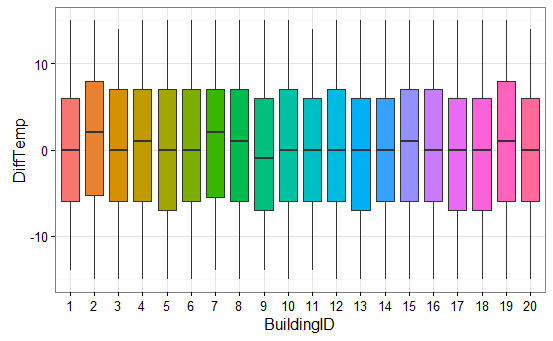

```r
library(ggplot2)
ggplot(build_temps, aes(x = BuildingID, y = DiffTemp, fill = BuildingID)) + geom_boxplot() + guides(fill = F) + theme_bw()
```

Similarily for country:

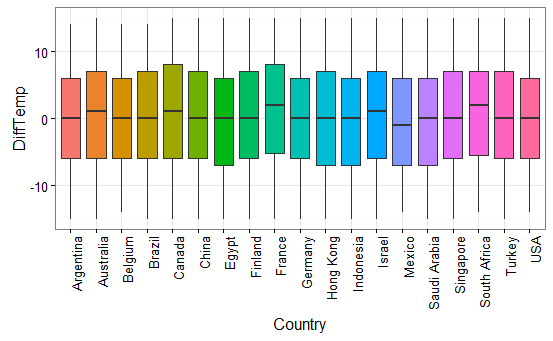

```r
ggplot(build_temps, aes(x = Country, y = DiffTemp, fill = Country)) + geom_boxplot() + guides(fill = F) + theme_bw() + theme(axis.text.x = element_text(angle = 90, hjust = 1))
```

Suppose we just want to see which buildings had the most frequent excursions in temperature, where we’ll define excursion as any data point where ActualTemp > TargetTemp.

We will use the `dplyr` package to aggregate the data.

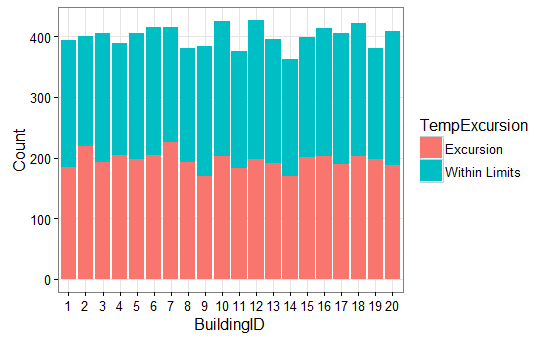

```r
library(dplyr)
build_temps <- build_temps %>% mutate(TempExcursion = ifelse(DiffTemp > 0, "Excursion", "Within Limits"), TempFlag = ifelse(DiffTemp > 0, 1, 0))
excursions <- build_temps %>% group_by(TempExcursion, BuildingID) %>% summarize(Count = n())
ggplot(excursions, aes(x = BuildingID, y = Count, fill = TempExcursion)) + geom_bar(stat = 'identity', position = 'stack') + theme_bw()
```

# Predicting Modeling with R

Let’s try to estimate the probability that there’ll be a temperature excursion given building temperature attributes.

## Split Data into Training and Validation Set

In order to evaluate our model, we will need a set that we can use to estimate/train our model, and then another set that we can test our model. The test set should be separate from our training set.

The base package in R has a handy function named `split` for splitting data by the values of one of it’s columns, and it returns a named list with an element for each value in the split column.

```r
range(build_temps$Date)
```

```
[1] "2013-06-01" "2013-06-30"
```

```r
build_temps$SplitValue <- ifelse(build_temps$Date > "2013-06-15", "Test", "Train")
split_df <- split(build_temps, build_temps$SplitValue)
names(split_df)
```

```
[1] "Test"  "Train"
```

```r
lapply(split_df, dim)
```

```
$Test
[1] 3995   16

$Train
[1] 4005   16
```

```r
lapply(split_df, function(x) range(x$Date))
```

```
$Test
[1] "2013-06-16" "2013-06-30"

$Train
[1] "2013-06-01" "2013-06-15"
```

## Train a Binomial Logistic Regression Model

Every modeling function in R starts with a formula to estimate. We will create our model formula, and then pass that to the `glm` function in the `stats` package to estimate a binary classification model, using the logistic link function.

```r
temp_formula <- TempFlag ~ BuildingID + BuildingMgr + BuildingAge + HVACproduct + Country + Time + System + SystemAge
train_model <- glm(temp_formula, family = 'binomial', data = split_df[["Train"]])
```

## Score Model on Test Set

Now that we have our trained model, we can score it on our test test.

```r
predictions <- predict(train_model, newdata = split_df[["Test"]],
                       type = 'response')
summary(predictions)
```

[output not shown]